# Implementing L1000 Performance Measure

Amir Asiaee

2023-03-23

# Getting Started

The goal of this report is to test the predictive performance of the L1000 genes on the TCGA dataset. First, we load some global information about where to find data folders.

```r
rm(list=ls())
source("00-paths.R")
ls()
```

```
## [1] "paths"
```

Next, we need to load their predictor genes. The data is coming from the supplementary material of the paper Table S2 L1000 Probes. Out of ~1000 genes 27 of them are not matched for in the TCGA data:

```r
l1k <- read.csv(file.path(paths$raw, "l1000.csv"))
l1k <- l1k[2:nrow(l1k),]

load(file.path(paths$scratch, "allMrnaNames.Rda"))
length(l1k$Gene.Symbol) - sum(l1k$Gene.Symbol %in% namesMrnaAll)
```

```
## [1] 27
```

Next, we load the TCGA data. Note that there is no further/separate normalization involved, we have the names for the predictors and outcomes.

```r
load(file = file.path(paths$clean, "matchedData.Rda"))
dim(mRNAdata)
```

```
## [1] 20289  8895
```

```r
X <- mRNAdata[rownames(mRNAdata) %in% l1k$Gene.Symbol, ]
dim(X)
```

```
## [1] 1031 8895
```

```r
Y <- mRNAdata[!(rownames(mRNAdata) %in% l1k$Gene.Symbol), ]
dim(Y)
```

```
## [1] 19258  8895
```

# Checking their R2 performance

Now the question is can our humble computer does the prediction (previously we could do it using 56 predictors but now the matrices are much bigger with 1000 predictors). Trying it out:

```r
library(ClassComparison)

f <- file.path(paths$scratch, "l1000MLM.Rda")
g <- file.path(paths$scratch, "l1000Residuals.Rda")
if (file.exists(f)) {
  load(f)
  load(g)
} else {
  l1000MLM <- MultiLinearModel(Y ~ ., t(X), Y)
  l1000Residuals <- Y - t(l1000MLM@predictions)
  save(l1000MLM,  file = f)
  save(l1000Residuals, file = g)
}
rm(f, g)
gc()
```

```
##             used   (Mb) gc trigger   (Mb)  max used   (Mb)
## Ncells    971290   51.9    1716978   91.7   1327794   71.0
## Vcells 735734533 5613.3 1062009008 8102.5 735755979 5613.4
```

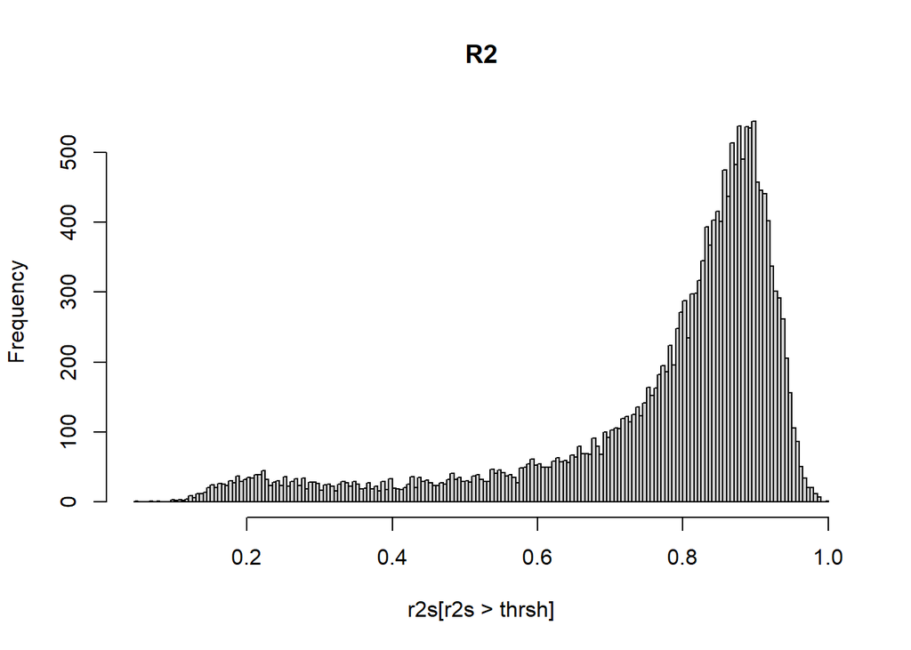

```
##    Min. 1st Qu.  Median    Mean 3rd Qu.    Max.
## 0.04604 0.73064 0.83695 0.77045 0.88900 1.00000
```

```r
saveAs <- "l1000R2"
histsR2(l1000Residuals, saveAs, N, dvar)
```

```r
# plotNsave(saveAs, 'jointMedoid-only-r2.png', 'Joint=(TF, miR) Model')
```

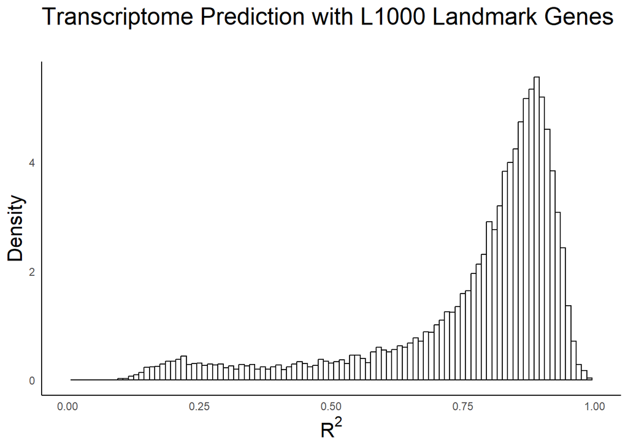

```r
library(ggplot2)
load(file.path(paths$scratch, 'l1000R2.Rda'))

theme_set(theme_minimal() +
            theme(axis.line = element_line(colour = "black"),
                  panel.grid.major = element_blank(),
                  panel.grid.minor = element_blank(),
                  panel.border = element_blank(),
                  panel.background = element_blank(),
                  title = element_text(size = 16)))

p0 <- NULL
  x <- seq(0, 1, len = length(r2s))
  p0 <- ggplot(as.data.frame(r2s), aes(r2s)) +
    geom_histogram(
      aes(y = ..density..),
      color = "black",
      fill = "white",
      binwidth = .01
    ) +
    xlab(expression(R ^ 2)) + ylab('Density') + ggtitle('Transcriptome Prediction with L1000 Landmark Genes\n\u200B') + xlim(c(0, 1))
print(p0)
```

# Checking their correlation performance

```r
f <- file.path(paths$scratch, "corl1000.Rda")
if (file.exists(f)) {
  load(f)
} else {
  load(file.path(paths$scratch, "l1000MLM.Rda"))
  Yhat <- t(l1000MLM@predictions)
  C <- cor(t(Y), t(Yhat))
  save(C, file = f)
}
dim(C)
```

```
## [1] 19258 19258
```

```r
f <- file.path(paths$scratch, "l1000Cor.Rda")
g <- file.path(paths$scratch, "nullL1000Cor.Rda")
if (file.exists(f)) {
  load(f)
  load(g)
} else {
  Ours <- diag(C)
  Null <- C[row(C) != col(C) & row(C) > col(C)]
  save(Ours, file = f)
  save(Null, file = g)
}
```

Plotting:

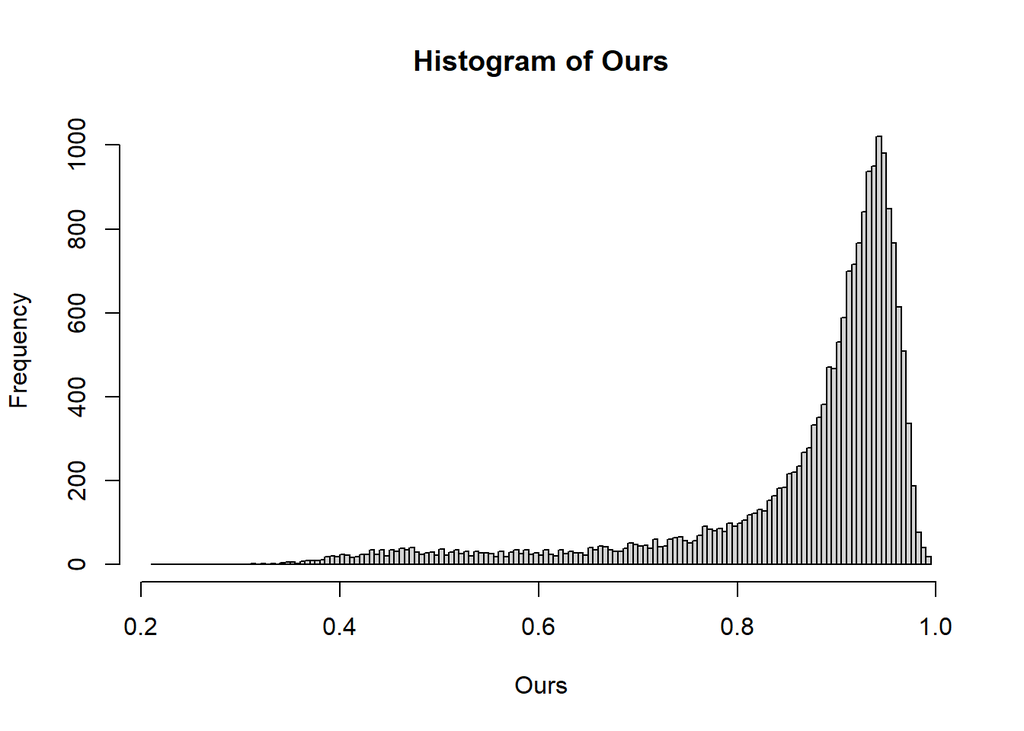

```r
hist(Ours, breaks = 123)
```

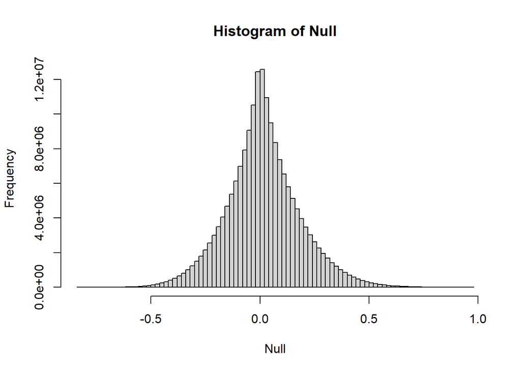

```r
hist(Null, breaks = 123)
```

Check the performance against the null:

```r
z <- quantile(Null, .95, na.rm = T)
z
```

```
##       95%
## 0.3067821
```

```r
print(paste("Our performance", sum(Ours > z, na.rm = T) / length(Ours)))
```

```
## [1] "Our performance 0.999792294111538"
```

# Appendix